# Random Forests

Arvind Venkatadri

13/06/2020

## 0.1 References:

1. Machine Learning Basics - Random Forest at [Shirin’s Playground](https://shirinsplayground.netlify.app/2018/10/ml_basics_rf/)

## 0.2 Penguin Random Forest Model with`randomForest`

Using the `penguins` dataset and Ramdom Forest Classification.

```r
penguins
```

| species | island | bill_length_mm | bill_depth_mm | flipper_length_mm | body_mass_g | sex | year |
| --- | --- | --- | --- | --- | --- | --- | --- |
| Adelie | Torgersen | 39.1 | 18.7 | 181 | 3750 | male | 2007 |
| Adelie | Torgersen | 39.5 | 17.4 | 186 | 3800 | female | 2007 |
| Adelie | Torgersen | 40.3 | 18.0 | 195 | 3250 | female | 2007 |
| Adelie | Torgersen | NA | NA | NA | NA | NA | 2007 |
| Adelie | Torgersen | 36.7 | 19.3 | 193 | 3450 | female | 2007 |
| Adelie | Torgersen | 39.3 | 20.6 | 190 | 3650 | male | 2007 |
| Adelie | Torgersen | 38.9 | 17.8 | 181 | 3625 | female | 2007 |
| Adelie | Torgersen | 39.2 | 19.6 | 195 | 4675 | male | 2007 |
| Adelie | Torgersen | 34.1 | 18.1 | 193 | 3475 | NA | 2007 |
| Adelie | Torgersen | 42.0 | 20.2 | 190 | 4250 | NA | 2007 |

[output cut: 334 more lines]

```r
summary(penguins)
```

```
      species          island    bill_length_mm
 Adelie   :152   Biscoe   :168   Min.   :32.10
 Chinstrap: 68   Dream    :124   1st Qu.:39.23
 Gentoo   :124   Torgersen: 52   Median :44.45
                                 Mean   :43.92
                                 3rd Qu.:48.50
                                 Max.   :59.60
                                 NA's   :2
 bill_depth_mm   flipper_length_mm  body_mass_g
 Min.   :13.10   Min.   :172.0     Min.   :2700
 1st Qu.:15.60   1st Qu.:190.0     1st Qu.:3550
 Median :17.30   Median :197.0     Median :4050
 Mean   :17.15   Mean   :200.9     Mean   :4202
 3rd Qu.:18.70   3rd Qu.:213.0     3rd Qu.:4750
 Max.   :21.50   Max.   :231.0     Max.   :6300
 NA's   :2       NA's   :2         NA's   :2
     sex           year
 female:165   Min.   :2007
 male  :168   1st Qu.:2007
 NA's  : 11   Median :2008
              Mean   :2008
              3rd Qu.:2009
              Max.   :2009
```

```r
penguins %>% skimr::skim()
```

```
-- Data Summary ------------------------
                           Values
Name                       Piped data
Number of rows             344
Number of columns          8
_______________________
Column type frequency:
  factor                   3
  numeric                  5
________________________
Group variables            None

-- Variable type: factor ------------------------------------
# A tibble: 3 x 6
  skim_variable n_missing complete_rate ordered n_unique
* <chr>             <int>         <dbl> <lgl>      <int>
1 species               0         1     FALSE          3
2 island                0         1     FALSE          3
3 sex                  11         0.968 FALSE          2
  top_counts
* <chr>
1 Ade: 152, Gen: 124, Chi: 68
2 Bis: 168, Dre: 124, Tor: 52
3 mal: 168, fem: 165

-- Variable type: numeric -----------------------------------
# A tibble: 5 x 11
  skim_variable     n_missing complete_rate   mean      sd
* <chr>                 <int>         <dbl>  <dbl>   <dbl>
1 bill_length_mm            2         0.994   43.9   5.46
2 bill_depth_mm             2         0.994   17.2   1.97
3 flipper_length_mm         2         0.994  201.   14.1
4 body_mass_g               2         0.994 4202.  802.
5 year                      0         1     2008.    0.818
      p0    p25    p50    p75   p100 hist
*  <dbl>  <dbl>  <dbl>  <dbl>  <dbl> <chr>
1   32.1   39.2   44.4   48.5   59.6 ▃▇▇▆▁
2   13.1   15.6   17.3   18.7   21.5 ▅▅▇▇▂
3  172    190    197    213    231   ▂▇▃▅▂
4 2700   3550   4050   4750   6300   ▃▇▆▃▂
5 2007   2007   2008   2009   2009   ▇▁▇▁▇
```

```r
penguins <- penguins %>% tidyr::drop_na()
# Spent one hour trying to find `drop-na()` ( 14 June 2020)
```

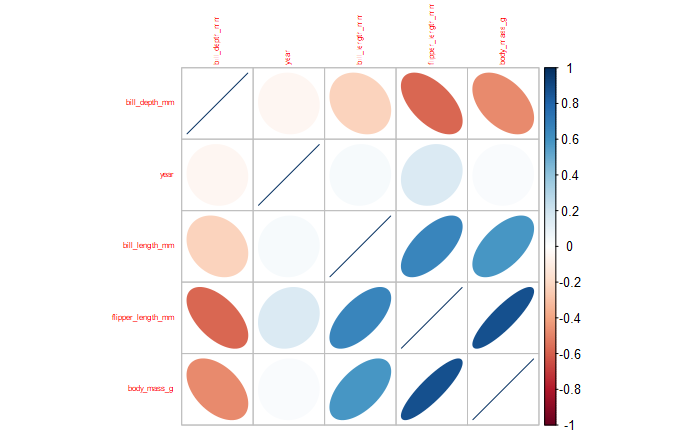

```r
# library(corrplot)
cor <- penguins %>% select(is.numeric) %>% cor()
cor %>% corrplot(., method = "ellipse", order = "hclust",tl.cex = 0.5)
```

```r
# try these too:
# cor %>% corrplot(., method = "square", order = "hclust",tl.cex = 0.5)
# cor %>% corrplot(., method = "color", order = "hclust",tl.cex = 0.5)
# cor %>% corrplot(., method = "shade", order = "hclust",tl.cex = 0.5)
```

Notes: - `flipper_length_mm` and `culmen_depth_mm` are negtively correlated at approx (-0.7) - `flipper_length_mm` and `body_mass_g` are positively correlated at approx 0.8

So we will use steps in the recipe to remove correlated variables.

### 0.2.1 Penguin Data Sampling and Recipe

```r
# Data Split
penguin_split <- initial_split(penguins, prop = 0.6)
penguin_train <- training(penguin_split)
penguin_test <- testing(penguin_split)
penguin_split
```

```
<Analysis/Assess/Total>
<199/134/333>
```

```r
head(penguin_train)
```

| species | island | bill_length_mm | bill_depth_mm | flipper_length_mm | body_mass_g | sex | year |
| --- | --- | --- | --- | --- | --- | --- | --- |
| Adelie | Biscoe | 35.3 | 18.9 | 187 | 3800 | female | 2007 |
| Adelie | Dream | 37.6 | 19.3 | 181 | 3300 | female | 2007 |
| Adelie | Dream | 41.3 | 20.3 | 194 | 3550 | male | 2008 |
| Gentoo | Biscoe | 47.4 | 14.6 | 212 | 4725 | female | 2009 |
| Gentoo | Biscoe | 47.6 | 14.5 | 215 | 5400 | male | 2007 |
| Adelie | Torgersen | 36.2 | 16.1 | 187 | 3550 | female | 2008 |

```r
# Recipe
penguin_recipe <- penguins %>%
  recipe(species ~ .) %>%
  step_normalize(all_numeric()) %>% # Scaling and Centering
  step_corr(all_numeric()) %>%  # Handling correlated variables
  prep()

# Baking the data
penguin_train_baked <-  penguin_train %>%
  bake(object = penguin_recipe, new_data = .)

penguin_test_baked <-  penguin_test %>%
  bake(object = penguin_recipe, new_data = .)

head(penguin_train_baked)
```

| island | bill_length_mm | bill_depth_mm | flipper_length_mm | body_mass_g | sex | year | species |
| --- | --- | --- | --- | --- | --- | --- | --- |
| Biscoe | -1.5895630 | 0.8811212 | -0.9965183 | -0.5055254 | female | -1.2818130 | Adelie |
| Dream | -1.1689853 | 1.0842457 | -1.4246077 | -1.1264770 | female | -1.2818130 | Adelie |
| Dream | -0.4924037 | 1.5920570 | -0.4970807 | -0.8160012 | male | -0.0517158 | Adelie |
| Biscoe | 0.6230415 | -1.3024673 | 0.7871873 | 0.6432349 | female | 1.1783814 | Gentoo |
| Biscoe | 0.6596135 | -1.3532485 | 1.0012320 | 1.4815195 | male | -1.2818130 | Gentoo |
| Torgersen | -1.4249891 | -0.5407504 | -0.9965183 | -0.8160012 | female | -0.0517158 | Adelie |

### 0.2.2 Penguin Random Forest Model

```r
penguin_model <-
  rand_forest(trees = 100) %>%
  set_engine("randomForest") %>%
  set_mode("classification")
penguin_model
```

```
Random Forest Model Specification (classification)

Main Arguments:
  trees = 100

Computational engine: randomForest
```

```r
penguin_fit <-
  penguin_model %>%
  fit(species ~ .,penguin_train_baked)
penguin_fit
```

```
parsnip model object

Fit time:  11ms

Call:
 randomForest(x = maybe_data_frame(x), y = y, ntree = ~100)
               Type of random forest: classification
                     Number of trees: 100
No. of variables tried at each split: 2

        OOB estimate of  error rate: 2.01%
Confusion matrix:
          Adelie Chinstrap Gentoo class.error
Adelie        87         1      0  0.01136364
Chinstrap      3        38      0  0.07317073
Gentoo         0         0     70  0.00000000
```

```r
# iris_ranger <-
#   rand_forest(trees = 100) %>%
#   set_mode("classification") %>%
#   set_engine("ranger") %>%
#   fit(Species ~ ., data = iris_training_baked)
```

### 0.2.3 Metrics for the Penguin Random Forest Model

```r
# Predictions
predict(object = penguin_fit, new_data = penguin_test_baked) %>%
  dplyr::bind_cols(penguin_test_baked) %>%
  glimpse()
```

```
Rows: 134
Columns: 9
$ .pred_class       <fct> Adelie, Adelie, Adelie, Adelie, A~
$ island            <fct> Torgersen, Torgersen, Torgersen, ~
$ bill_length_mm    <dbl> -0.8215515, -0.6752636, -0.858123~
$ bill_depth_mm     <dbl> 0.1194043, 0.4240910, 1.7444004, ~
$ flipper_length_mm <dbl> -1.0678666, -0.4257325, -0.782473~
$ body_mass_g       <dbl> -0.505525421, -1.188572125, -0.69~
$ sex               <fct> female, female, male, female, mal~
$ year              <dbl> -1.2818130, -1.2818130, -1.281813~
$ species           <fct> Adelie, Adelie, Adelie, Adelie, A~
```

```r
# Prediction Accuracy Metrics
predict(object = penguin_fit, new_data = penguin_test_baked) %>%
  dplyr::bind_cols(penguin_test_baked) %>%
  yardstick::metrics(truth = species, estimate = .pred_class)
```

| .metric | .estimator | .estimate |
| --- | --- | --- |
| accuracy | multiclass | 0.9925373 |
| kap | multiclass | 0.9883407 |

```r
# Prediction Probabilities
penguin_fit_probs <-
  predict(penguin_fit, penguin_test_baked, type = "prob") %>%
  dplyr::bind_cols(penguin_test_baked)
glimpse(penguin_fit_probs)
```

```
Rows: 134
Columns: 11
$ .pred_Adelie      <dbl> 0.91, 0.96, 1.00, 0.96, 1.00, 0.9~
$ .pred_Chinstrap   <dbl> 0.08, 0.04, 0.00, 0.04, 0.00, 0.0~
$ .pred_Gentoo      <dbl> 0.01, 0.00, 0.00, 0.00, 0.00, 0.0~
$ island            <fct> Torgersen, Torgersen, Torgersen, ~
$ bill_length_mm    <dbl> -0.8215515, -0.6752636, -0.858123~
$ bill_depth_mm     <dbl> 0.1194043, 0.4240910, 1.7444004, ~
$ flipper_length_mm <dbl> -1.0678666, -0.4257325, -0.782473~
$ body_mass_g       <dbl> -0.505525421, -1.188572125, -0.69~
$ sex               <fct> female, female, male, female, mal~
$ year              <dbl> -1.2818130, -1.2818130, -1.281813~
$ species           <fct> Adelie, Adelie, Adelie, Adelie, A~
```

```r
# Confusion Matrix
penguin_fit$fit$confusion %>% tidy()
```

[output not shown]

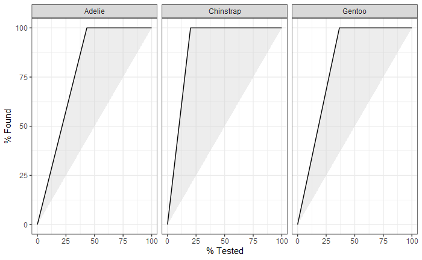

```r
# Gain Curves
penguin_fit_probs %>%
  yardstick::gain_curve(species, .pred_Adelie:.pred_Gentoo) %>%
  autoplot()
```

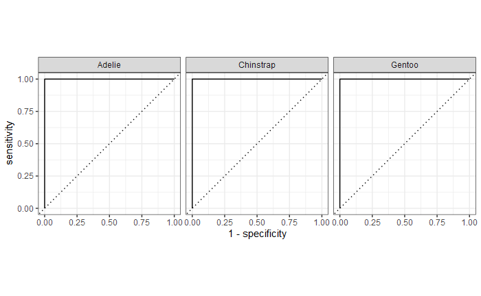

```r
# ROC Plot
penguin_fit_probs%>%
  roc_curve(species, .pred_Adelie:.pred_Gentoo) %>%
  autoplot()
```

### 0.2.4 Using `broom` on the penguin model

```r
penguin_split
```

```
<Analysis/Assess/Total>
<199/134/333>
```

```r
penguin_split %>% broom::tidy()
```

| Row | Data |
| --- | --- |
| 1 | Analysis |
| 4 | Analysis |
| 7 | Analysis |
| 8 | Analysis |
| 10 | Analysis |
| 11 | Analysis |
| 12 | Analysis |
| 13 | Analysis |
| 16 | Analysis |
| 18 | Analysis |

[output cut: 323 more lines]

```r
penguin_recipe %>% broom::tidy()
```

| number | operation | type | trained | skip | id |
| --- | --- | --- | --- | --- | --- |
| 1 | step | normalize | TRUE | FALSE | normalize_mmNlA |
| 2 | step | corr | TRUE | FALSE | corr_xIsZk |

```r
# Following do not work for `random forest models` !! ;-()
#penguin_model %>% tidy()
#penguin_fit %>% tidy()
penguin_model %>% str()
```

```
List of 5
 $ args    :List of 3
  ..$ mtry : language ~NULL
  .. ..- attr(*, ".Environment")=<environment: R_EmptyEnv>
  ..$ trees: language ~100
  .. ..- attr(*, ".Environment")=<environment: R_EmptyEnv>
  ..$ min_n: language ~NULL
  .. ..- attr(*, ".Environment")=<environment: R_EmptyEnv>
 $ eng_args: Named list()
  ..- attr(*, "class")= chr [1:2] "quosures" "list"
 $ mode    : chr "classification"
 $ method  : NULL
 $ engine  : chr "randomForest"
 - attr(*, "class")= chr [1:2] "rand_forest" "model_spec"
```

```r
penguin_test_baked
```

| island | bill_length_mm | bill_depth_mm | flipper_length_mm | body_mass_g | sex | year | species |
| --- | --- | --- | --- | --- | --- | --- | --- |
| Torgersen | -0.82155152 | 0.11940428 | -1.067866553 | -0.505525421 | female | -1.2818130 | Adelie |
| Torgersen | -0.67526362 | 0.42409105 | -0.425732512 | -1.188572125 | female | -1.2818130 | Adelie |
| Torgersen | -0.85812350 | 1.74440040 | -0.782473646 | -0.691810886 | male | -1.2818130 | Adelie |
| Torgersen | -0.93126744 | 0.32252879 | -1.424607687 | -0.722858463 | female | -1.2818130 | Adelie |
| Torgersen | -0.98612541 | 2.04908718 | -0.711125419 | -0.505525421 | male | -1.2818130 | Adelie |
| Torgersen | -1.75413687 | 0.62721557 | -1.210563007 | -1.095429393 | female | -1.2818130 | Adelie |
| Torgersen | 0.36703766 | 2.20143056 | -0.497080739 | -0.008764181 | male | -1.2818130 | Adelie |
| Biscoe | -1.15069929 | 0.77955895 | -1.495955914 | -0.753906041 | male | -1.2818130 | Adelie |
| Biscoe | -0.62040566 | 0.72877782 | -1.281911233 | -0.816001196 | male | -1.2818130 | Adelie |
| Biscoe | -0.63869165 | 0.37330992 | -0.996518326 | -1.250667280 | female | -1.2818130 | Adelie |

[output cut: 124 more lines]

```r
NA
NA
```

## 0.3 Iris Random Forest Model with `ranger`

Using the `iris` dataset and Random Forest Classification. This part uses `rsample` to split the data and the `recipes` to *prep* the data for model making.

```r
#set.seed(100)
iris_split <- rsample::initial_split(iris, prop = 0.6)
iris_split
```

```
<Analysis/Assess/Total>
<90/60/150>
```

```r
iris_split %>% training() %>% glimpse()
```

```
Rows: 90
Columns: 5
$ Sepal.Length <dbl> 5.2, 5.0, 6.7, 7.7, 6.7, 6.3, 7.7, 5.4~
$ Sepal.Width  <dbl> 3.5, 3.5, 3.1, 2.6, 2.5, 2.5, 3.0, 3.4~
$ Petal.Length <dbl> 1.5, 1.3, 4.7, 6.9, 5.8, 5.0, 6.1, 1.7~
$ Petal.Width  <dbl> 0.2, 0.3, 1.5, 2.3, 1.8, 1.9, 2.3, 0.2~
$ Species      <fct> setosa, setosa, versicolor, virginica,~
```

```r
iris_split %>% testing() %>% glimpse()
```

```
Rows: 60
Columns: 5
$ Sepal.Length <dbl> 5.1, 4.9, 4.6, 5.0, 4.9, 5.4, 5.8, 5.4~
$ Sepal.Width  <dbl> 3.5, 3.0, 3.1, 3.4, 3.1, 3.7, 4.0, 3.9~
$ Petal.Length <dbl> 1.4, 1.4, 1.5, 1.5, 1.5, 1.5, 1.2, 1.3~
$ Petal.Width  <dbl> 0.2, 0.2, 0.2, 0.2, 0.1, 0.2, 0.2, 0.4~
$ Species      <fct> setosa, setosa, setosa, setosa, setosa~
```

### 0.3.1 Iris Data Pre-Processing: Creating the Recipe

The `recipes` package provides an interface that specializes in *data pre-processing*. Within the package, the functions that start, or execute, the data transformations are named after **cooking actions**. That makes the interface more user-friendly. For example:

- `recipe()` - Starts a new set of transformations to be applied, similar to the `ggplot()` command. Its main argument is the model’s `formula`.
- `prep()` - Executes the transformations on top of the data that is supplied (**typically, the training data**). Each data transformation is a `step()` function. ( Recall what we did with the `caret` package: *Centering, Scaling, Removing Correlated variables*…)

Note that in order to avoid data leakage (e.g: transferring information from the train set into the test set), data should be “prepped” using the **train_tbl** only. https://towardsdatascience.com/modelling-with-tidymodels-and-parsnip-bae2c01c131c CRAN: The idea is that the preprocessing operations will all be **created** using the *training set* and then these steps will be **applied** to both the training and test set.

```r
# Pre Processing the Training Data

iris_recipe <-
  training(iris_split) %>% # Note: Using TRAINING data !!
  recipe(Species ~ .)      # Note: Outcomes ~ Predictors !!

# The data contained in the `data` argument need not be the training set; this data is only used to catalog the names of the variables and their types (e.g. numeric, etc.).
```

Q: How does the recipe “figure” out which are the outcomes and which are the predictors? A.The `recipe` command defines `Outcomes` and `Predictors` using the formula interface. Not clear how this recipe “figures” out which are the outcomes and which are the predictors, when we have not yet specified them…

Q. Why is the recipe not agnostic to data set? Is that a meaningful question? A. The use of the `training set` in the recipe command is just to declare the variables and specify the `roles` of the data, nothing else. `Roles` are open-ended and extensible. From https://cran.r-project.org/web/packages/recipes/vignettes/Simple_Example.html :

> This document demonstrates some basic uses of recipes. First, some definitions are required: - **variables** are the original (raw) data columns in a data frame or tibble. For example, in a traditional formula Y ~ A + B + A:B, the variables are A, B, and Y. - **roles** define how variables will be used in the model. Examples are: `predictor` (independent variables), `response`, and `case weight`. This is meant to be open-ended and extensible. - **terms** are columns in a **design matrix** such as A, B, and A:B. These can be other derived entities that are grouped, such as a set of `principal components` or a set of columns, that define a `basis function` for a variable. These are synonymous with `features` in machine learning. Variables that have `predictor` roles would automatically be main `effect terms`.

```r
# Apply the transformation steps
iris_recipe <- iris_recipe %>%
  step_corr(all_predictors()) %>%
  step_center(all_predictors(), -all_outcomes()) %>%
  step_scale(all_predictors(), -all_outcomes()) %>%
  prep()
```

This has created the `recipe()` and prepped it too. We now need to apply it to our datasets:

- Take `training` data and `bake()` it to prepare it for modelling.
- Do the same for the `testing` set.

```r
iris_training_baked <-
  iris_split %>%
  training() %>%
  bake(iris_recipe,.)
iris_training_baked
```

| Sepal.Length | Sepal.Width | Petal.Width | Species |
| --- | --- | --- | --- |
| -0.8280047 | 1.09127066 | -1.44918454 | setosa |
| -1.0695620 | 1.09127066 | -1.31402743 | setosa |
| 0.9836749 | 0.16252967 | 0.30785785 | versicolor |
| 2.1914614 | -0.99839656 | 1.38911471 | virginica |
| 0.9836749 | -1.23058180 | 0.71332918 | virginica |
| 0.5005604 | -1.23058180 | 0.84848628 | virginica |
| 2.1914614 | -0.06965557 | 1.38911471 | virginica |
| -0.5864474 | 0.85908541 | -1.44918454 | setosa |
| 1.5875681 | -0.06965557 | 0.44301496 | virginica |
| -1.0695620 | 0.39471492 | -1.44918454 | setosa |

[output cut: 80 more lines]

```r
iris_testing_baked <-
  iris_split %>%
  testing() %>%
  bake(iris_recipe,.)
iris_testing_baked
```

| Sepal.Length | Sepal.Width | Petal.Width | Species |
| --- | --- | --- | --- |
| -0.9487833 | 1.09127066 | -1.44918454 | setosa |
| -1.1903406 | -0.06965557 | -1.44918454 | setosa |
| -1.5526765 | 0.16252967 | -1.44918454 | setosa |
| -1.0695620 | 0.85908541 | -1.44918454 | setosa |
| -1.1903406 | 0.16252967 | -1.58434164 | setosa |
| -0.5864474 | 1.55564115 | -1.44918454 | setosa |
| -0.1033328 | 2.25219689 | -1.44918454 | setosa |
| -0.5864474 | 2.02001164 | -1.17887032 | setosa |
| -0.9487833 | 1.09127066 | -1.31402743 | setosa |
| -0.2241115 | 1.78782639 | -1.31402743 | setosa |

[output cut: 50 more lines]

### 0.3.2 Iris Model Training using `parsnip`

Different ML packages provide different interfaces (APIs ) to do the same thing (e.g random forests). The `tidymodels` package provides a consistent interface to invoke a wide variety of packages supporting a wide variety of models.

The `parsnip` package is a successor to `caret`.

To model with `parsnip`: 1. Pick a `model` : 2. Set the `engine` 3. Set the `mode` (if needed): *Classification* or *Regression*

Check [here](https://tidymodels.github.io/parsnip/articles/articles/Models.html) for models available in `parsnip`.

- Mode: *classification* and *regression* in `parsnip`, each using a variety of models. ( **Which Way**). This defines the form of the output.
- Engine: The `engine` is the **R package** that is invoked by `parsnip` to execute the model. E.g `glm`, `glmnet`,`keras`.( **How** ) `parsnip` provides **wrappers** for models from these packages.
- Model: is the **specific technique** used for the modelling task. E.g `linear_reg()`, `logistic_reg()`, `mars`, `decision_tree`, `nearest_neighbour`…(What model).

and models have: - `hyperparameters`: that are numerical or factor variables that `tune` the model ( Like the alpha beta parameters for Bayesian priors)

We can use the `random forest` model to **classify** the iris into species. Here Species is the `Outcome` variable and the rest are `predictor` variables. The `random forest` model is provided by the `ranger` package, to which `tidymodels/parsnip` provides a simple and consistent interface.

```r
library(ranger)
iris_ranger <-
  rand_forest(trees = 100) %>%
  set_mode("classification") %>%
  set_engine("ranger") %>%
  fit(Species ~ ., data = iris_training_baked)
```

`ranger` can generate random forest models for `classification`, `regression`, `survival`( time series, time to event stuff). `Extreme Forests` are also supported, wherein all points in the dataset are used ( instead of bootstrap samples) along with `feature bagging`. We can also run the same model using the `randomForest` package:

```r
library(randomForest,quietly = TRUE)
iris_rf <-
  rand_forest(trees = 100) %>%
  set_mode("classification") %>%
  set_engine("randomForest") %>%
  fit(Species ~ ., data = iris_training_baked)
```

### 0.3.3 Iris Predictions

The `predict()` function run against a `parsnip` model returns a prediction `tibble`. By default, the prediction variable is called `.pred_class`.

```r
predict(object = iris_ranger, new_data = iris_testing_baked) %>%
  dplyr::bind_cols(iris_testing_baked) %>%
  glimpse()
```

```
Rows: 60
Columns: 5
$ .pred_class  <fct> setosa, setosa, setosa, setosa, setosa~
$ Sepal.Length <dbl> -0.9487833, -1.1903406, -1.5526765, -1~
$ Sepal.Width  <dbl> 1.09127066, -0.06965557, 0.16252967, 0~
$ Petal.Width  <dbl> -1.449185, -1.449185, -1.449185, -1.44~
$ Species      <fct> setosa, setosa, setosa, setosa, setosa~
```

### 0.3.4 Iris Classification Model Validation

We use `metrics()` function from the `yardstick` package to evaluate how good the model is.

```r
predict(iris_ranger, iris_testing_baked) %>%
  dplyr::bind_cols(iris_testing_baked) %>%
  yardstick::metrics(truth = Species, estimate = .pred_class)
```

| .metric | .estimator | .estimate |
| --- | --- | --- |
| accuracy | multiclass | 0.9166667 |
| kap | multiclass | 0.8735245 |

We can also check the metrics for `randomForest` model:

```r
predict(iris_rf, iris_testing_baked) %>%
  dplyr::bind_cols(iris_testing_baked) %>%
  yardstick::metrics(truth = Species, estimate = .pred_class)
```

| .metric | .estimator | .estimate |
| --- | --- | --- |
| accuracy | multiclass | 0.9000000 |
| kap | multiclass | 0.8484848 |

### 0.3.5 Iris Per-Classifier Metrics

We can use the parameter `type = "prob"` in the `predict()` function to obtain a probability score on each prediction. **TBD: How is this prob calculated?** Possible answer: the Random Forest model outputs its answer by majority voting across n trees. Each of the possible answers( i.e. predictions) for a particular test datum gets a share of the vote, that represents its probability. Hence each dataum in the test vector can show a probability for the “winning” answer. ( Quite possibly we can get the probabilities for *all possible outcomes* for **each test datum**)

```r
iris_ranger_probs <-
  predict(iris_ranger, iris_testing_baked, type = "prob") %>%
  dplyr::bind_cols(iris_testing_baked)
glimpse(iris_ranger_probs)
```

```
Rows: 60
Columns: 7
$ .pred_setosa     <dbl> 0.9965714, 0.8874729, 0.8919286, 0~
$ .pred_versicolor <dbl> 0.003428571, 0.083700280, 0.080412~
$ .pred_virginica  <dbl> 0.000000000, 0.028826797, 0.027658~
$ Sepal.Length     <dbl> -0.9487833, -1.1903406, -1.5526765~
$ Sepal.Width      <dbl> 1.09127066, -0.06965557, 0.1625296~
$ Petal.Width      <dbl> -1.449185, -1.449185, -1.449185, -~
$ Species          <fct> setosa, setosa, setosa, setosa, se~
```

```r
iris_rf_probs <-
  predict(iris_rf, iris_testing_baked, type = "prob") %>%
  dplyr::bind_cols(iris_testing_baked)
glimpse(iris_rf_probs)
```

```
Rows: 60
Columns: 7
$ .pred_setosa     <dbl> 1.00, 0.94, 0.93, 1.00, 0.90, 1.00~
$ .pred_versicolor <dbl> 0.00, 0.06, 0.06, 0.00, 0.09, 0.00~
$ .pred_virginica  <dbl> 0.00, 0.00, 0.01, 0.00, 0.01, 0.00~
$ Sepal.Length     <dbl> -0.9487833, -1.1903406, -1.5526765~
$ Sepal.Width      <dbl> 1.09127066, -0.06965557, 0.1625296~
$ Petal.Width      <dbl> -1.449185, -1.449185, -1.449185, -~
$ Species          <fct> setosa, setosa, setosa, setosa, se~
```

```r
# Tabulating the probabilities
ftable(iris_rf_probs$.pred_versicolor)
```

```
  0 0.01 0.02 0.04 0.06 0.07 0.09 0.12 0.17 0.18 0.2 0.22 0.27 0.36 0.39 0.41 0.81 0.83 0.84 0.86 0.88 0.89 0.92 0.93 0.94 0.95 0.97 0.98

 12    6    4    2    3    1    3    1    1    1   3    1    1    1    1    1    2    1    1    1    2    1    2    1    1    1    4    1
```

```r
ftable(iris_rf_probs$.pred_virginica)
```

```
  0 0.01 0.02 0.03 0.04 0.05 0.06 0.07 0.08 0.11 0.12 0.14 0.15 0.16 0.17 0.59 0.63 0.7 0.77 0.79 0.82 0.91 0.93 0.94 0.96 0.97 0.98 0.99  1

 19    6    1    1    1    3    1    1    1    2    1    1    1    2    1    1    1   1    1    2    1    1    1    1    1    2    1    2  2
```

```r
ftable(iris_rf_probs$.pred_setosa)
```

```
  0 0.01 0.02 0.03 0.04 0.05 0.06 0.54 0.77 0.8 0.83 0.9 0.92 0.93 0.94 0.96 0.98 0.99  1

 16   11    2    3    2    1    1    1    1   1    1   2    1    1    1    1    1    4  9
```

[output not shown]

```r
iris_rf_probs %>%
  yardstick::gain_curve(Species, .pred_setosa:.pred_virginica) %>%
  glimpse()

iris_rf_probs %>%
  yardstick::gain_curve(Species, .pred_setosa:.pred_virginica) %>%
  autoplot()

iris_rf_probs %>%
  yardstick::roc_curve(Species, .pred_setosa:.pred_virginica) %>%
  glimpse()

iris_rf_probs %>%
  yardstick::roc_curve(Species, .pred_setosa:.pred_virginica) %>%
  autoplot()
```

[output not shown]

### 0.3.6 Iris Classifier: Metrics

```r
predict(iris_ranger, iris_testing_baked, type = "prob") %>%
  bind_cols(predict(iris_ranger,iris_testing_baked)) %>%
  bind_cols(select(iris_testing_baked,Species)) %>%
  glimpse()


predict(iris_ranger, iris_testing_baked, type = "prob") %>%
  bind_cols(predict(iris_ranger,iris_testing_baked)) %>%
  bind_cols(select(iris_testing_baked,Species)) %>%
  yardstick::metrics(data = ., truth = Species, estimate = .pred_class, ... = .pred_setosa:.pred_virginica)


# And for the `randomForest`method

predict(iris_rf, iris_testing_baked, type = "prob") %>%
  bind_cols(predict(iris_ranger,iris_testing_baked)) %>%
  bind_cols(select(iris_testing_baked,Species)) %>%
  glimpse()

predict(iris_rf, iris_testing_baked, type = "prob") %>%
  bind_cols(predict(iris_ranger,iris_testing_baked)) %>%
  bind_cols(select(iris_testing_baked,Species)) %>%
  yardstick::metrics(data = ., truth = Species, estimate = .pred_class, ... = .pred_setosa:.pred_virginica)
```

[output not shown]